# Prediction of 2023 Presidential Election Winner (Using Tweets from Twitter about each candidates for Sentiment Analysis)

## by Idongesit Inyang

## Introduction

Forecasting and analysis of election results have gained a wide popularity in the field of political methodology, a subfield of political science and political analysis concerned with the study quantitative and qualitative approaches used to understand politics and political systems.

Sentiment analysis has been used to predict the opinions of the citizens on US election using Twitter data. The authors used 17,000 tweets to train their model (Naïve Bayes) and the model achieved a less than 60% prediction accuracy by classifying the tweets into positive, negative, neutral and not-sure and this assisted them in analyzing real time tweets from the people which gave great insights about public opinions on each candidate.

# What is the number of tweets recieved for each candidate?

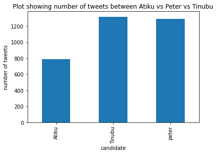

# What Location has the highest number of Tweets?

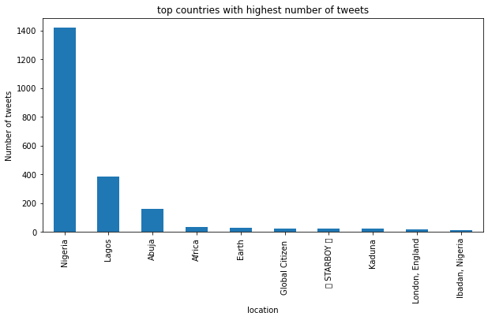

# Sentiment analysis of presidential elections

# Peter Obi tweets sentiment analysis

|  | text | location | cleantext | subjectivity | polarity | analysis |
| --- | --- | --- | --- | --- | --- | --- |
| 0 | Reuben Abati’s question to Peter obi pertainin... | Nigeria | reuben abati question peter obi pertaining pri... | 0.241667 | 0.116667 | positive |
| 1 | Gist 101: A thread 👇\nSo I was in this Salon e... | Nigeria | gist thread salon earlier today playing petero... | 0.250000 | 0.000000 | neutral |
| 2 | Peter Obi in 2010 was ICT Governor of the Year... | Nigeria | peter obi ict governor year west africa ict de... | 0.000000 | 0.000000 | neutral |
| 3 | This is how you can convince me to vote for yo... | Nigeria | convince vote candidate fkeyamo bring party ma... | 0.000000 | 0.000000 | neutral |
| 4 | Banking halls in Nigeria became football viewi... | Nigeria | banking hall nigeria became football viewing c... | 0.100000 | -0.100000 | negative |
| ... | ... | ... | ... | ... | ... | ... |
| 548 | On my watch those who steal government money w... | Nigeria | watch steal government money meet bargain pete... | 0.000000 | 0.000000 | neutral |
| 549 | This brought tears to my eyes. I think Peter O... | Nigeria | brought tear eye think peter obi decision issu... | 0.650000 | 0.275000 | positive |
| 550 | ‘If You Put A Gun To My Head, I Won’t Reveal H... | Nigeria | put gun head reveal going deal insecurity nige... | 0.000000 | 0.000000 | neutral |
| 551 | ‘If You Put A Gun To My Head, I Won’t Reveal H... | Nigeria | put gun head reveal going deal insecurity nige... | 0.000000 | 0.000000 | neutral |
| 552 | "I was the first Governor ever in Nigeria to a... | Nigeria | first governor ever nigeria approach unhabitat... | 0.340278 | -0.020833 | negative |

553 rows × 6 columns

# Plot Graph for analysis of Peter Obi Tweets

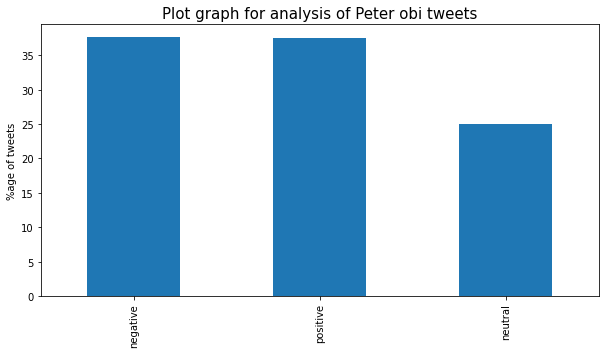

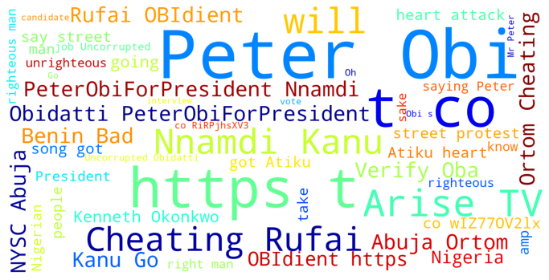

# Atiku sentiment analysis

[figure not shown]

# Plot graph for analysis of Atiku's tweets

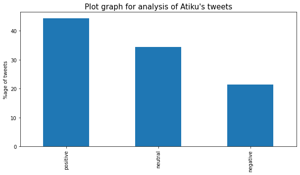

# Tinubu Sentiment Analysis

### wordcloud for Tinubu

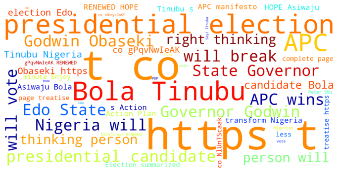

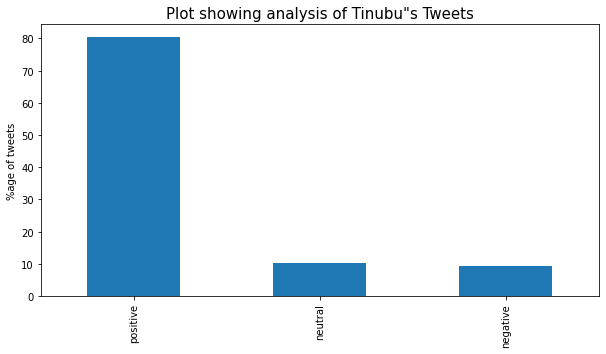

# Conclusion

According to sentiment analysism Tinubu has upper hand over Atiku and Peter Obi in Nigeria which actually matters in presidential elections.

[output not shown]